# Analiza danych krystalograficznych

06 grudnia, 2018

# 1. Wstęp

Chemicy i fizycy wykorzystują krystalografię jako jedną z najdokładniejszych metod określania struktury i budowy cząsteczek. Naświetlane promieniami rentgenowskimi kryształy odbijają uderzające w nie promienie, które są nagrywane przez aparat cyfrowy. Obraz z aparatu, po wzięciu pod uwagę interferencji i innych zjawisk zachodzących podczas przechodzenia promieni przez kryształy, stanowi podstawę do stworzenia map intensywności, czyli obrazów 3D określających prawdopodobieństwo występowania pierwiastków w przestrzeni. Takie mapy są następnie analizowane przez chemików, fizyków i biologów, którzy określają typy pierwiastków i połączenia między nimi.

Od pewnego czasu krystalografia pozwala określać budowę nie tylko małych cząsteczek, ale także większych struktur takich jak białka. Przy strukturach tak dużych i skomplikowanych jak białka, ręczne określenie wszystkich pierwiastków jest pracą długą i podatną na błędy. Stąd potrzeba rozwijania metod automatycznej analizy fragmentów map intensywności.

Celem projektu jest analiza danych krystalograficznych i ocena możliwości wykorzystania uczenia maszynowego do automatycznego podpowiadania biologom jakie cząsteczki mogą się kryć w niewymodelowanych fragmentach map intensywności.

# 1.1 Opis danych

Dane do realizacji analizy pochodzą z bazy Protein Data Bank (PDB), gdzie przechowywane są dane strukturalne białek oraz innych związków chemicznych. Punktem zainteresowania tej analizy są małe cząsteczki (ligandy), które potrafią wiązać się z niektórymi białkami. Struktury zgromadzone w bazie PDB zostały pobrane i przetworzane, aby wybrać informacje tylko o ligandach i zakodować je w postaci kolumn opisanych poniżej. Opis każdego liganda oparty jest o trójwymiarowy fragment gęstości elektronowej struktury (tzw. maskę), czyli w uproszczeniu obraz 3D. Z jednego wpisu do bazy PDB może powstać kilka wierszy opisujących zawarte w strukturze ligandy.

# 2. Specyfikacja

# 2.1. Powtarzalność wyników

Zakładając identyczny plik wejściowy, powtarzalność wyników zapewniają konfiguracje ziarna wartości losowych np. `set.seed(x)`.

# 2.2. Użyte biblioteki

W poniższej analizie zostały wykorzystane następujące biblioteki: - knitr - do generowania raportu z R+markdown - tidyr - do czyszczenia danych

3. ładowanie danych

```r
d <- read.csv(file="all_summary.csv", nrows=10000, header=TRUE, sep=";")
```

4.Usuwanie wierszy o podanej klasie

```r
forbiddenValues <- list("UNK", "UNX", "UNL", "DUM", "N", "BLOB", "ALA", "ARG", "ASN", "ASP", "CYS", "GLN", "GLU", "GLY", "HIS", "ILE", "LEU", "LYS", "MET", "MSE", "PHE", "PRO", "SEC", "SER", "THR", "TRP", "TYR", "VAL", "DA", "DG", "DT", "DC", "DU", "A", "G", "T", "C", "U", "HOH", "H20", "WAT","UNK", "UNX", "UNL", "DUM", "N", "BLOB", "ALA", "ARG", "ASN", "ASP", "CYS", "GLN", "GLU", "GLY", "HIS", "ILE", "LEU", "LYS", "MET", "MSE", "PHE", "PRO", "SEC", "SER", "THR", "TRP", "TYR", "VAL", "DA", "DG", "DT", "DC", "DU", "A", "G", "T", "C", "U", "HOH", "H20", "WAT")

clean <- subset(d, !(res_name %in% forbiddenValues))
rm(forbiddenValues)
```

5. Uzupełnienie brakujących danych

```r
library(knitr)
# liczba kolumn, w których brakuje danych
length(colnames(clean)[ apply(clean, 2, anyNA) ])
```

```
## [1] 200
```

```r
getMostCommon <- function(x) {
        names(which.max(table(x)))
}

# predykcja brakujących danych
filled <- apply(clean[,colnames(clean) %in% colnames(clean)[ apply(clean, 2, anyNA) ]],
      2,
      getMostCommon)
dim(clean)
```

```
## [1] 9940  412
```

6. Podstawowe statystyki

```r
library(knitr)
knitr::kable(summary(filled))
```

|  | Length | Class | Mode |
| --- | --- | --- | --- |
| res_name | 1 | -none- | character |
| dict_atom_non_h_count | 1 | -none- | character |
| dict_atom_non_h_electron_sum | 1 | -none- | character |
| dict_atom_C_count | 1 | -none- | character |
| dict_atom_N_count | 1 | -none- | character |
| dict_atom_O_count | 1 | -none- | character |
| dict_atom_S_count | 1 | -none- | character |
| part_01_shape_O3 | 1 | -none- | character |
| part_01_shape_O4 | 1 | -none- | character |
| part_01_shape_O5 | 1 | -none- | character |
| part_01_shape_FL | 1 | -none- | character |
| part_01_shape_O3_norm | 1 | -none- | character |
| part_01_shape_O4_norm | 1 | -none- | character |
| part_01_shape_O5_norm | 1 | -none- | character |
| part_01_shape_FL_norm | 1 | -none- | character |
| part_01_shape_I1 | 1 | -none- | character |
| part_01_shape_I2 | 1 | -none- | character |
| part_01_shape_I3 | 1 | -none- | character |
| part_01_shape_I4 | 1 | -none- | character |
| part_01_shape_I5 | 1 | -none- | character |
| part_01_shape_I6 | 1 | -none- | character |
| part_01_shape_I1_norm | 1 | -none- | character |
| part_01_shape_I2_norm | 1 | -none- | character |
| part_01_shape_I3_norm | 1 | -none- | character |
| part_01_shape_I4_norm | 1 | -none- | character |
| part_01_shape_I5_norm | 1 | -none- | character |
| part_01_shape_I6_norm | 1 | -none- | character |
| part_01_shape_M000 | 1 | -none- | character |
| part_01_shape_CI | 1 | -none- | character |
| part_01_shape_E3_E1 | 1 | -none- | character |

[output cut: 170 more lines]

```r
rm(filled)
```

7. Kod ograniczający liczbę klas (res_name) do 50 najpopularniejszych wartości.

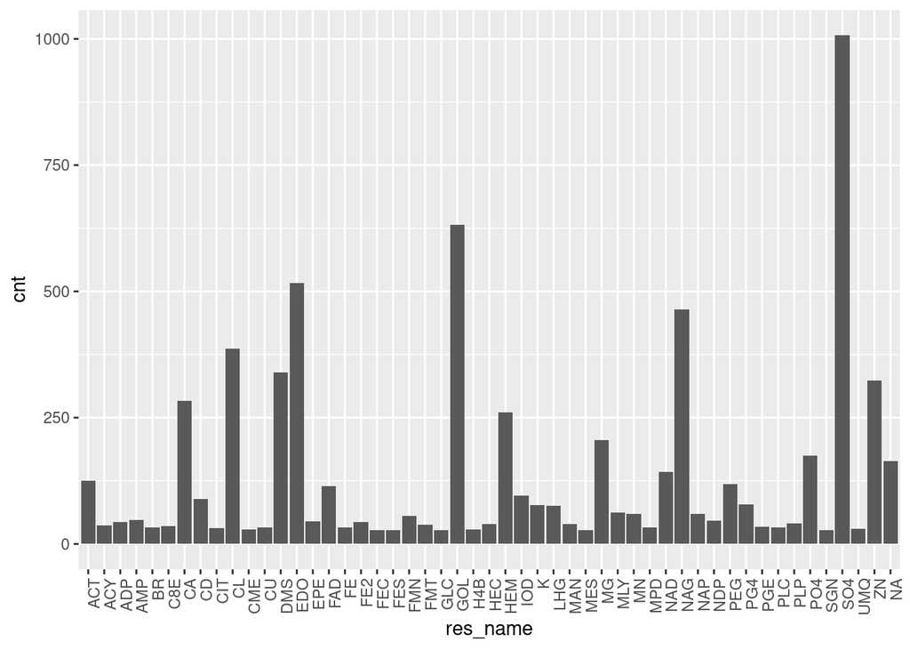

```r
library(dplyr)
library(ggplot2)
ggplot(clean %>%
  group_by(res_name) %>%
  summarise(cnt=n()) %>%
  top_n(50), aes(x=res_name, y=cnt)) +
  geom_bar(stat = "identity") +
  theme(axis.text.x = element_text(angle = 90, hjust = 1))
```

8. Sekcję sprawdzającą korelacje między zmiennymi; sekcja ta powinna zawierać jakąś formę graficznej prezentacji korelacji.

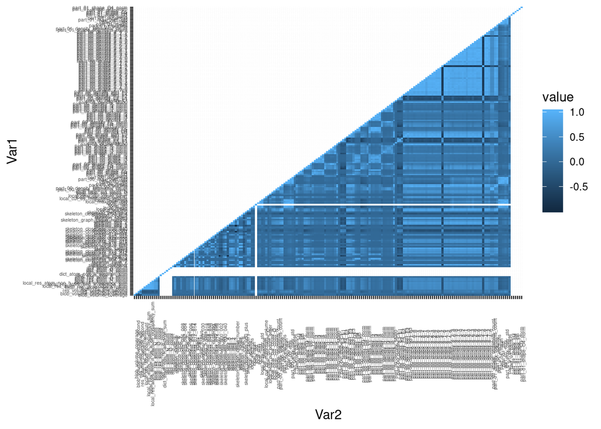

```r
library(dplyr)
library(reshape2)
library(ggplot2)

# ogranicz heatmap do macierzy trójkątnej
get_upper_tri <- function(cormat){
    cormat[lower.tri(cormat)]<- NA
    return(cormat)
}

#sortuj po wartościach
reorder_cormat <- function(cormat){
  dd <- as.dist((1-cormat)/2)
  hc <- hclust(dd)
  cormat <-cormat[hc$order, hc$order]
}

correlation <- cor(select_if(clean[,8:200], function(x){is.numeric(x) && !is.na(x)}))
ggplot(data=melt(get_upper_tri(correlation), na.rm = TRUE), aes(x=Var2, y=Var1, fill=value))+
  geom_tile()+
  theme(axis.text.x=element_text(size=4, angle=90))+
  theme(axis.text.y=element_text(size=4))
```

```r
# czyszczenie pamięci
rm(correlation)
```